# Kansas Voter Registration File - 2024-06-24

Earl F Glynn

2024-07-11

TO DO:

- Mailing addresses in separate file for inspection
- Name has to identify possible duplicate entries

Script to perform quality checks and produce frequency counts of many fields in the Kansas voter registration file.

**History**

- Convert very old R script to markdown and tidyverse | 2019-01-26
- Programmatically “fix” one Geary County voter with extra tabs in the `text_mail_address` fields. This has been a problem since 2006!! | 2023-03-21

**Output Files**

- `County-Voter-Election-Code-Summary.xlsx`
- `Statewide-Election-Code-Summary.xlsx`
- `Statewide-Election-Codes-by-Voter.txt`
- `Statewide-Field-Length-Summary.xlsx`
- `Statewide-Voters-Missing-District-Info.xlsx`
- `Counts-by-Precinct.xlsx`
- `Counts-by-County.xlsx`
- `Counts-State.xlsx`
- `Statewide-Fixed.txt` - fix GE County tab problem, header consistency
- `Statewide-Updated.txt` - add additional useful variables for analysis
- `Counts` folder with CSV file of frequency counts by field

# 1 Backstage

## 1.1

## 1.2 Constants

Use 5-year census intervals (except for interval 18-19)

```r
ageBreaks <- 5 * 3:17
ageBreaks[1] <- 18
```

[1] 18 20 25 30 35 40 45 50 55 60 65 70 75 80 85

```r
ageIntervals <-
  c(paste(ageBreaks[-length(ageBreaks)], ageBreaks[-1]-1, sep = "-"),
    paste0(ageBreaks[length(ageBreaks)], "+"))
ageIntervals[1] <- "18-19"
```

[1] “18-19” “20-24” “25-29” “30-34” “35-39” “40-44” “45-49” “50-54” “55-59” “60-64” [11] “65-69” “70-74” “75-79” “80-84” “85+”

## 1.3 Packages

```r
library(tidyverse)
```

```r
library(writexl)
library(kableExtra)
```

```r
library(lubridate)   # date/time functions
library(gplots)      # heatmap.2
```

```r
library(scales)      # comma
```

## 1.4 Helper Function

```r
Show <- function(data, caption="", bigMark="",
                 height = NULL, width = NULL, ...)
{
  data                                       |>
  kable("html", caption=caption,
        format.args=list(big.mark=bigMark))  |>
  kable_styling(bootstrap_options=c("striped", "bordered", "condensed"),
                position="left",
                full_width=FALSE, ...)       |>
  scroll_box(height = height, width = width)
}
```

# 2 Character Quality Check

Check for unusual characters using `CharCount` utility from [github](https://github.com/EarlGlynn/CharCount). This shows the count of the 256 possible 8-bit bytes in the file. Look for changes from recent files.

The `CharCount` table will confirm whether the field separator is a tab (x09) vs a comma (x2C), and identify possible problem characters

Screen shot of running CharCount is saved to file `CharCount.png` for inclusion here.

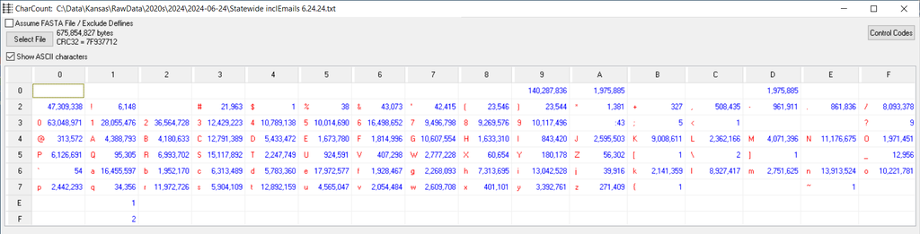

Problems can include x’E1’ and x’F1’. Failure to fix these characters can cause problems.

See use of `iconv` below.

# 3 Raw data file

## 3.1 Parameters

```r
cat("Raw Data: ",       params$RAW_DATA_FILE,
    "\nFixed File: ",   params$FIXED_DATA_FILE,
    "\nUpdated File: ", params$UPDATED_DATA_FILE,
    "\nElection Date (for age computations): ", params$ELECTION_DATE, "\n")
```

```
Raw Data:  Statewide inclEmails 6.24.24.txt
Fixed File:  Statewide-Fixed.txt
Updated File:  Statewide-Updated.txt
Election Date (for age computations):  2024-08-06
```

## 3.2 Fix problems in file programmatically

Since 2006 records with too many tabs are from Geary County.

Fix encoding issue, since text is not interpreted as a valid string because it contains non-ASCII characters.

```r
rawLines <-
  read_lines(params$RAW_DATA_FILE)       |>
  iconv(from = "ISO-8859-1", to = "UTF-8")

length(rawLines)
```

```
[1] 1975885
```

### 3.2.1 Make header like rest of data records.

Add tab to end of header row; make it like other data lines with final tab.

Maybe someday the Kansas Secretary of State’s Office could fix this anomaly?

This makes the header row tab terminated, like the rest of the data.

But, there will be a blank last column that needs to be deleted.

```r
rawLines[1] <- paste(rawLines[1], "\t", sep="")
```

### 3.2.2 Fix problem Geary County record

Only one left! [Problem started in 2006!!]

See `C:\Data\Kansas\RawData\2020s\2023\2023-02-13\Geary-County-Parse-Problem.docx`

```r
verify1 <- grep("778 TC CO\t\t5302 ASHBY AVE\t", rawLines)
length(verify1)
```

```
[1] 1
```

```r
rawLines <- gsub("778 TC CO\t\t5302 ASHBY AVE\t",
                 "778 TC CO\t5302 ASHBY AVE",
                 rawLines)
```

### 3.2.3 Fix Multiple Districts

Assigning a voter to multiple State Rep districts should NEVER happen.

State Rep District

- “KR0124,KR0125” in Seward County in May 2024 -> “KR0125”
- “KR0054,KR0076” in Osage County in June 2024 -> “KR0076” (verify this)

```r
rawLines <- gsub("KR0054,KR0076", "KR0076", rawLines)
```

### 3.2.4 Create `Fixed` data

```r
write_lines(rawLines, params$FIXED_DATA_FILE)
```

## 3.3 Delimiter Check

- With fixes above, all records should parse consistently. Let’s check.
- Without `comment.char` override, records with # characters are problems.
- Without `quote` override, records with apostrophes or quotation marks are problems.

```r
counts <- tibble(fieldCounts = count.fields(params$FIXED_DATA_FILE, sep="\t", comment.char="", quote=""))
```

```r
freqCounts <-
  counts                                |>
  group_by(fieldCounts)                 |>
  summarize(n = n(), .groups = "drop")  |>
  ungroup()

freqCounts |>
    Show(bigMark = ",")
```

| fieldCounts | n |
| --- | --- |
| 72 | 1,975,885 |

All records should have the same number of fields.

## 3.4 Read fixed file

```r
voters <- read_delim(params$FIXED_DATA_FILE, "\t",
                     quote = "",
                     comment = "",
                     na = character(),  # some people might names of "NA"
                     col_types = cols(.default = "c"),
                     progress = FALSE)
```

```r
dim(voters)
```

```
[1] 1975884      72
```

There is an extra column R created because of the tab at the end of each line. (Tabs are “separators” not “terminators”.)

Verify final unwanted column has no info.

```r
table(voters[,ncol(voters)], useNA="ifany")
```

```
...72

1975884
```

Get rid of unwanted column

```r
voters <- voters[,-ncol(voters)]
```

```r
glimpse(voters)
```

```
Rows: 1,975,884
Columns: 71
$ db_logid                    <chr> "Allen", "Allen", "Allen", "Allen", "Allen…
$ cde_registrant_status       <chr> "A   ", "I   ", "A   ", "A   ", "I   ", "A…
$ cde_name_title              <chr> "", "", "", "", "", "", "", "", "", "", ""…
$ text_name_first             <chr> "Craig", "George", "Georgia", "James", "Je…
$ text_name_middle            <chr> "Melton", "Edward", "Mae", "Carson", "E", …
$ text_name_last              <chr> "Abbott", "Abbott", "Abbott", "Abbott", "A…
$ cde_name_suffix             <chr> "", "", "", "", "", "", "", "", "", "", ""…
$ cde_gender                  <chr> "M   ", "M   ", "F   ", "F   ", "F   ", "F…
$ text_registrant_id          <chr> "4482236", "4479777", "4472179", "6393408"…
$ registrant_text_email       <chr> "", "", "", "", "", "", "", "", "", "JNJAD…
$ text_res_address_nbr        <chr> "9", "210", "9", "104", "210", "815", "72"…
$ text_res_address_nbr_suffix <chr> "", "", "", "", "", "", "", "", "", "", ""…
$ cde_street_dir_prefix       <chr> "", "", "", "", "", "N   ", "", "S   ", "N…
```

[output cut: 58 more lines]

Verify current political parties (new ones added in 2024):

```r
table(voters$desc_party, useNA = "ifany")
```

```
                       Democratic      Libertarian No Labels Kansas
               1           504651            24358              313
      Republican     Unaffiliated    United Kansas
          877632           568899               30
```

Genders

```r
table(voters$cde_gender, useNA = "ifany")
```

```
           F       M       U
   3130 1027582  937011    8161
```

## 3.5 Problem precincts 2024-05-02, 2024-06-24

For now, use “majority vote” to pick district

### 3.5.1 DG Lawrence 42 S2 H46

```r
dg1 <-
  voters |>
  filter(db_logid           == "Douglas",
         precinct_text_name == "Lawrence 42 S2 H46")

dim(dg1)
```

```
[1] 427  71
```

```r
write_xlsx(dg1, "Precinct-Douglas-Lawrence-42-S2-H46.xlsx")
```

```r
table(dg1$district_ks)
```

```
KS0002 KS0019
   423      4
```

```r
table(dg1$district_kr)
```

```
KR0045 KR0046
     4    423
```

```r
select <- voters$db_logid           == "Douglas"  &
          voters$precinct_text_name == "Lawrence 42 S2 H46"
sum(select)
```

```
[1] 427
```

```r
voters$district_ks[which(select)] <- "KS0002"
voters$district_kr[which(select)] <- "KR0046"
```

### 3.5.2 MG Fawn Creek Twp CC2

```r
mg1 <-
  voters |>
  filter(db_logid           == "Montgomery",
         precinct_text_name == "Fawn Creek  Twp CC2")

dim(mg1)
```

```
[1] 1068   71
```

```r
write_xlsx(mg1, "Precinct-Montgomery-Fawn Creek-Twp-CC2.xlsx")
```

```r
table(mg1$district_kr)
```

```
KR0011 KR0012
   728    340
```

```r
table(mg1$district_cc)
```

```
CC02 CC03
 559  509
```

```r
select <- voters$db_logid           == "Montgomery"  &
          voters$precinct_text_name == "Fawn Creek  Twp CC2"
sum(select)
```

```
[1] 1068
```

```r
voters$district_kr[which(select)] <- "KR0011"
voters$district_cc[which(select)] <- "CC02"
```

## 3.6 RL Manhattan Twp 3

```r
rla <-
  voters |>
  filter(db_logid           == "Riley",
         precinct_text_name == "Manhattan Twp 3  ")

dim(rla)
```

```
[1] 155  71
```

```r
write_xlsx(rla, "Riley-Manhattan-Twp-3.xlsx")
```

```r
table(rla$district_kr)
```

```
KR0067 KR0068
   150      5
```

```r
select <- voters$db_logid           == "Riley"  &
          voters$precinct_text_name == "Manhattan Twp 3  "
sum(select)
```

```
[1] 155
```

```r
voters$district_kr[which(select)] <- "KR0067"
```

## 3.7 RL Manhattan Twp 4

```r
rlb <-
  voters |>
  filter(db_logid           == "Riley",
         precinct_text_name == "Manhattan Twp 4  ")

dim(rlb)
```

```
[1] 580  71
```

```r
write_xlsx(rlb, "Riley-Manhattan-Twp-4.xlsx")
```

```r
table(rlb$district_kr)
```

```
KR0051 KR0061 KR0064
    12    239    329
```

```r
select <- voters$db_logid           == "Riley"  &
          voters$precinct_text_name == "Manhattan Twp 4  "
sum(select)
```

```
[1] 580
```

```r
voters$district_kr[which(select)] <- "KR0064"
```

## 3.8 RL Wildcat Twp

```r
rlc <-
  voters |>
  filter(db_logid           == "Riley",
         precinct_text_name == "Wildcat Twp ")

dim(rlc)
```

```
[1] 660  71
```

```r
write_xlsx(rlc, "Riley-Wildcat-Twp.xlsx")
```

```r
table(rlc$district_kr, useNA = "ifany")
```

```
KR0064 KR0067
   658      2
```

```r
select <- voters$db_logid           == "Riley"  &
          voters$precinct_text_name == "Wildcat Twp "
sum(select)
```

```
[1] 660
```

```r
voters$district_kr[which(select)] <- "KR0064"
```

# 4 Cleanup / Fixups / Add new variables

Let’s get rid of leading/trailing blanks in many fields.

’County`should NEVER have been named`db_logid`

```r
votersModified <-
  voters                                                                  |>
  rename(County = db_logid)                                               |>
  mutate(
          cde_registrant_status     = str_trim(cde_registrant_status) |>
                                      str_to_upper(),  # Lower case happened once

          # many fields have leading blanks to trim -- should probably trim all fields
          cde_name_title              = str_trim(cde_name_title),
          cde_name_suffix             = str_trim(cde_name_suffix),
          text_res_address_nbr_suffix = str_trim(text_res_address_nbr_suffix),
          registrant_text_email       = str_trim(registrant_text_email),
          cde_street_dir_prefix       = str_trim(cde_street_dir_prefix),
          cde_street_type             = str_trim(cde_street_type),
          cde_street_dir_suffix       = str_trim(cde_street_dir_suffix),
          cde_res_unit_type           = str_trim(cde_res_unit_type),
          text_res_unit_nbr           = str_trim(text_res_unit_nbr),
          text_res_zip5               = str_trim(text_res_zip5),
          text_res_zip4               = str_trim(text_res_zip4),
          text_mail_address1          = str_trim(text_mail_address1),
          text_mail_address2          = str_trim(text_mail_address2),
          text_mail_address3          = str_trim(text_mail_address3),
          text_mail_address4          = str_trim(text_mail_address4),
          text_mail_city              = str_trim(text_mail_city),
          text_mail_zip5              = str_trim(text_mail_zip5),
          text_mail_zip4              = str_trim(text_mail_zip4),
          text_res_carrier_rte        = str_trim(text_res_carrier_rte),
          text_mail_carrier_rte       = str_trim(text_mail_carrier_rte),
          text_phone_exchange         = str_trim(text_phone_exchange),
          text_phone_last_four        = str_trim(text_phone_last_four),

          text_election_code_1        = str_trim(text_election_code_1),
          text_election_code_2        = str_trim(text_election_code_2),
          text_election_code_3        = str_trim(text_election_code_3),
          text_election_code_4        = str_trim(text_election_code_4),
          text_election_code_5        = str_trim(text_election_code_5),
          text_election_code_6        = str_trim(text_election_code_6),
          text_election_code_7        = str_trim(text_election_code_7),
          text_election_code_8        = str_trim(text_election_code_8),
          text_election_code_9        = str_trim(text_election_code_9),
          text_election_code_10       = str_trim(text_election_code_10),
          polling_place_text_zip5     = str_trim(polling_place_text_zip5),
          polling_place_text_zip4     = str_trim(polling_place_text_zip4),
          district_jd                 = str_trim(district_jd),
          district_sd                 = str_trim(district_sd),

          text_res_physical_address = str_trim(text_res_physical_address),

          phone                     = paste(text_phone_area_code,
                                            text_phone_exchange,
                                            text_phone_last_four, sep = "-"),

          cde_gender                = if_else(cde_gender == "", "U", str_trim(cde_gender)),
          cde_gender                = recode(cde_gender,
                                             .missing = "U"),

          desc_party                = if_else(desc_party  == "", "Unaffiliated", str_trim(desc_party)),
          desc_party                = recode(desc_party,
                                             .missing = "Unaffiliated"),

          Party                     = case_match(desc_party,
                                                  "Democratic"       ~ "D",
                                                  "Libertarian"      ~ "L",
                                                  "No Labels Kansas" ~ "N",   # new in 2024
                                                  "Republican"       ~ "R",
                                                  "Unaffiliated"     ~ "U",
                                                  "United Kansas"    ~ "K"    # new in 2024
                                                ),

          precinct_text_designation = str_trim(precinct_text_designation),
          precinct_text_name        = str_trim(precinct_text_name),  # needed for some counties
          precinct                  = paste(County,
                                            precinct_text_name, precinct_text_designation,
                                            sep = "|"),

     #     precinct_part_text_designation = str_trim(precinct_part_text_designation),
     #     precinct_part_text_name        = str_trim(precinct_part_text_name),
     #     precinctPart                   = paste(County, precinct_part_text_name,
     #                                            precinct_part_text_designation, sep = "|"),

          addressHousehold = paste(text_res_address_nbr,
                                   text_res_address_nbr_suffix,
                                   cde_street_dir_prefix, text_street_name, cde_street_type,
                                   cde_res_unit_type, text_res_unit_nbr,
                                   text_res_city,
                                   text_res_zip5,
                                   sep = "|"),
          nameHousehold    = paste(text_name_last, addressHousehold, sep = "|"),

          RegisterDate     = mdy(date_of_registration),
          RegisterYear     = lubridate::year(RegisterDate),       # Use for cleanup
          RegisterMonth    = lubridate::month(RegisterDate),
          Registered       = (RegisterDate %--% lubridate::ymd(params$ELECTION_DATE)) / years(1),

          BirthDate        = mdy(date_of_birth),
          BirthYear        = lubridate::year(BirthDate),          # Use for cleanup
          BirthMonth       = lubridate::month(BirthDate),
          Age              = round((BirthDate %--% lubridate::ymd(params$ELECTION_DATE)) / years(1)),
          AgeInterval      = cut(Age,
                                 breaks = c(ageBreaks, Inf),
                                 right = FALSE,
                                 labels = ageIntervals),
          AgeRegistered    = round( as.numeric( mdy(date_of_registration)  -
                                                mdy(date_of_birth) ) / 365.25, 2)
        )

nrow(votersModified)
```

```
[1] 1975884
```

```r
write_tsv(votersModified, params$UPDATED_DATA_FILE)
```

**June 2024 data problem**

Fix Osage county voters not assigned to a congressional district -> 2nd District #####

Related to voters assigned to two State Rep districts.

```r
table(votersModified$district_cg, useNA = "ifany")
```

```
       CG0001 CG0002 CG0003 CG0004
   286 471118 479085 545940 479455
```

```r
select <- (votersModified$County      == "Osage" &
           votersModified$district_cg == " ")       |>
          which()

length(select)
```

```
[1] 286
```

Osage County is in CG0002

```r
votersModified$district_cg[select] <- "CG0002"
```

```r
table(votersModified$district_cg)
```

```
CG0001 CG0002 CG0003 CG0004
471118 479371 545940 479455
```

# 5 Stats for State

## 5.1 Status

```r
table(votersModified$cde_registrant_status, useNA = "ifany")
```

```
      A       I
1832108  143776
```

## 5.2 Party

```r
table(votersModified$desc_party, useNA = "ifany")
```

```
      Democratic      Libertarian No Labels Kansas       Republican
          504651            24358              313           877632
    Unaffiliated    United Kansas
          568900               30
```

```r
table(votersModified$Party, useNA = "ifany")
```

```
     D      K      L      N      R      U
504651     30  24358    313 877632 568900
```

## 5.3 Gender

```r
table(votersModified$cde_gender, useNA = "ifany")
```

```
      F       M       U
1027582  937011   11291
```

## 5.4 Age

```r
fivenum(votersModified$Age)
```

```
[1]   18   34   49   66 1074
```

```r
table(votersModified$Age, useNA = "ifany")
```

```
   18    19    20    21    22    23    24    25    26    27    28    29    30
 4385 16768 23213 27112 32317 32872 34436 33898 34849 33398 34148 34044 34389
   31    32    33    34    35    36    37    38    39    40    41    42    43
33819 34301 33791 35072 34066 33885 32762 33506 33622 33655 32841 33736 33089
   44    45    46    47    48    49    50    51    52    53    54    55    56
33405 31437 29858 29687 28568 27734 27778 26708 27466 28854 30802 29565 28459
   57    58    59    60    61    62    63    64    65    66    67    68    69
27397 28293 28998 31426 32585 33439 33643 33989 33306 32612 32604 32268 30908
   70    71    72    73    74    75    76    77    78    79    80    81    82
30562 28868 28286 26478 24497 23498 22404 22159 20035 15008 14843 14404 13471
   83    84    85    86    87    88    89    90    91    92    93    94    95
11487 10102  8940  8452  7457  6671  5668  5156  4195  3731  3132  2609  2019
   96    97    98    99   100   101   102   103   104   105   106   107   108
 1584  1296   859   642   462   329   225   178   110    95    52    27    22
  109   110   111   112   113   114   115   116   117   118   119   120   121
   17    11    12     9     8     5     2     5     3     1     2     2     1
  122   123   124   125   133   224   225  1074
    1     2    12     6     1     6     1     1
```

```r
table(votersModified$AgeInterval, useNA = "ifany")
```

```
 18-19  20-24  25-29  30-34  35-39  40-44  45-49  50-54  55-59  60-64  65-69
 21153 149950 170337 171372 167841 166726 147284 141608 142712 165082 161698
 70-74  75-79  80-84    85+
138691 103104  64307  64019
```

```r
countsState <-
  votersModified  |>
  summarize(
             n             = n(),
             Voters        = n_distinct(text_registrant_id),

             nCounty       = n_distinct(County),    # verify none are missing
             nCommissioner = n_distinct(district_cc),

             nCongress      = n_distinct(district_cg),
             nKSSenate      = n_distinct(district_ks),
             nKSHouse       = n_distinct(district_kr),
             nKSStateBoard  = n_distinct(district_sb),
             nKSSchoolBoard = n_distinct(district_sd),

             City           = n_distinct(text_res_city),
             Precinct       = n_distinct(precinct),
        #     PrecinctPart   = n_distinct(precinctPart),

             Email          = n_distinct(registrant_text_email),
             Phone          = n_distinct(phone),
             AddressHousehold = n_distinct(addressHousehold),
             NameHousehold    = n_distinct(nameHousehold),

             Female         = sum(cde_gender == "F", na.rm = TRUE),
             Male           = sum(cde_gender == "M", na.rm = TRUE),
             Unknown        = sum(cde_gender == "U", na.rm = TRUE),

             Democratic     = sum(desc_party == "Democratic",       na.rm = TRUE),
             Republican     = sum(desc_party == "Republican",       na.rm = TRUE),
             Libertarian    = sum(desc_party == "Libertarian",      na.rm = TRUE),
             NoLabels       = sum(desc_party == "No Labels Kansas", na.rm = TRUE),
             UnitedKansas   = sum(desc_party == "United Kansas",    na.rm = TRUE),
             Unaffilated    = sum(desc_party == "Unaffiliated"    , na.rm = TRUE),

             Active           = sum(cde_registrant_status == "A"),
             Inactive         = sum(cde_registrant_status == "I"),
             FractionInactive = Inactive / (Active + Inactive)
           )

countsState |> Show(bigMark = ",")
```

| n | Voters | nCounty | nCommissioner | nCongress | nKSSenate | nKSHouse | nKSStateBoard | nKSSchoolBoard | City | Precinct | Email | Phone | AddressHousehold | NameHousehold | Female | Male | Unknown | Democratic | Republican | Libertarian | NoLabels | UnitedKansas | Unaffilated | Active | Inactive | FractionInactive |
| --- | --- | --- | --- | --- | --- | --- | --- | --- | --- | --- | --- | --- | --- | --- | --- | --- | --- | --- | --- | --- | --- | --- | --- | --- | --- | --- |
| 1,975,884 | 1,975,884 | 105 | 32 | 4 | 40 | 125 | 10 | 455 | 726 | 4,078 | 301,561 | 1,169,503 | 1,034,741 | 1,344,819 | 1,027,582 | 937,011 | 11,291 | 504,651 | 877,632 | 24,358 | 313 | 30 | 568,900 | 1,832,108 | 143,776 | 0.0727654 |

```r
write_xlsx(countsState, paste0("Counts-State-", params$FILE_DATE, ".xlsx"))
```

## 5.5 Crosstabs

### 5.5.1 `date_of_registration`: Year by Month

```r
byYearMonth <-
  votersModified                         |>
  select(RegisterYear, RegisterMonth)    |>
  group_by(RegisterYear, RegisterMonth)  |>
  count()                                |>
  arrange(RegisterYear, RegisterMonth)   |>
  collect()                              |>
  spread(RegisterMonth, n, fill = 0)     |>
  ungroup()

dim(byYearMonth)
```

```
[1] 100  13
```

```r
write_xlsx(byYearMonth, paste0("Crosstab-RegisterYear-by-RegisterMonth-", params$FILE_DATE, ".xlsx"))
```

```r
byYearMonth |> Show(height = "400px")
```

| RegisterYear | 1 | 2 | 3 | 4 | 5 | 6 | 7 | 8 | 9 | 10 | 11 | 12 |
| --- | --- | --- | --- | --- | --- | --- | --- | --- | --- | --- | --- | --- |
| 20 | 0 | 0 | 0 | 0 | 0 | 0 | 0 | 1 | 0 | 0 | 0 | 0 |
| 24 | 0 | 1 | 0 | 0 | 0 | 0 | 0 | 0 | 0 | 0 | 0 | 0 |
| 200 | 0 | 0 | 0 | 0 | 0 | 0 | 1 | 0 | 0 | 0 | 0 | 0 |
| 202 | 0 | 0 | 0 | 0 | 0 | 1 | 0 | 0 | 1 | 1 | 0 | 0 |
| 210 | 0 | 1 | 0 | 0 | 0 | 0 | 0 | 0 | 0 | 0 | 0 | 0 |
| 220 | 0 | 0 | 0 | 0 | 0 | 0 | 0 | 0 | 2 | 0 | 0 | 0 |
| 222 | 0 | 0 | 0 | 0 | 0 | 0 | 0 | 0 | 2 | 0 | 0 | 0 |
| 230 | 0 | 0 | 0 | 0 | 0 | 0 | 0 | 0 | 1 | 0 | 1 | 0 |
| 240 | 0 | 1 | 0 | 0 | 0 | 0 | 0 | 0 | 0 | 0 | 0 | 0 |
| 1800 | 20 | 0 | 0 | 0 | 0 | 0 | 0 | 0 | 0 | 0 | 0 | 0 |
| 1801 | 10 | 0 | 0 | 0 | 0 | 0 | 0 | 0 | 0 | 0 | 0 | 0 |
| 1900 | 0 | 0 | 0 | 0 | 0 | 1 | 2 | 6 | 0 | 1 | 1 | 0 |
| 1901 | 207 | 0 | 0 | 0 | 0 | 0 | 0 | 0 | 0 | 0 | 0 | 0 |
| 1902 | 0 | 0 | 0 | 0 | 0 | 0 | 0 | 0 | 1 | 0 | 0 | 1 |
| 1903 | 1 | 0 | 0 | 0 | 0 | 0 | 0 | 0 | 0 | 0 | 0 | 0 |
| 1907 | 0 | 0 | 0 | 0 | 0 | 0 | 0 | 0 | 0 | 0 | 1 | 0 |
| 1908 | 0 | 0 | 0 | 0 | 0 | 0 | 0 | 1 | 0 | 0 | 0 | 0 |
| 1916 | 0 | 0 | 0 | 0 | 0 | 0 | 0 | 0 | 1 | 0 | 0 | 0 |
| 1933 | 0 | 1 | 0 | 0 | 0 | 0 | 0 | 0 | 0 | 0 | 0 | 0 |
| 1941 | 0 | 0 | 0 | 0 | 0 | 0 | 0 | 1 | 0 | 0 | 0 | 0 |
| 1944 | 0 | 0 | 0 | 0 | 0 | 0 | 0 | 0 | 1 | 2 | 0 | 0 |
| 1946 | 1 | 0 | 0 | 0 | 1 | 0 | 0 | 0 | 0 | 1 | 0 | 0 |
| 1948 | 0 | 0 | 1 | 0 | 0 | 0 | 2 | 0 | 0 | 0 | 0 | 0 |
| 1949 | 0 | 0 | 0 | 0 | 0 | 0 | 0 | 0 | 1 | 0 | 0 | 0 |
| 1950 | 2 | 0 | 0 | 0 | 0 | 0 | 2 | 0 | 0 | 1 | 0 | 0 |
| 1951 | 0 | 0 | 1 | 0 | 0 | 0 | 0 | 0 | 0 | 0 | 0 | 0 |
| 1952 | 1 | 0 | 2 | 2 | 4 | 0 | 4 | 1 | 2 | 5 | 0 | 0 |
| 1953 | 0 | 0 | 0 | 0 | 1 | 0 | 0 | 1 | 0 | 0 | 0 | 0 |
| 1954 | 0 | 1 | 1 | 1 | 2 | 2 | 10 | 0 | 2 | 9 | 2 | 1 |
| 1955 | 1 | 1 | 6 | 1 | 1 | 0 | 1 | 0 | 0 | 0 | 0 | 0 |

[output cut: 70 more lines]

Graphic

```r
byYearMonthRegister <-
  byYearMonth |>
  select(RegisterYear, `1`:`12`)   |>
  filter(RegisterYear >= 2012,
         RegisterYear <= 2024)
```

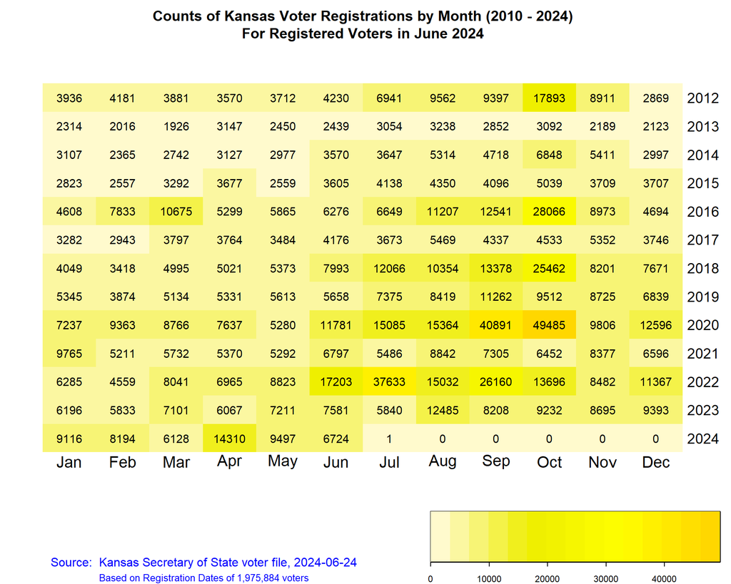

```r
options(scipen=999)  # suppress scientific notation in legend

colorPalette <- colorRampPalette(c("lemonchiffon", "yellow2", "yellow1", "gold"))
lmat <- rbind( c(0, 3, 3),  # layout matrix
               c(2, 1, 1),
               c(0, 0, 4))
lwid <- c(0.5, 4, 4)        # entry fo r each column in layout matrix
lhei <- c(1, 5, 1)          # entry for each row in layout matrix
yearMonthMatrix <- as.matrix(data.frame(byYearMonthRegister, row.names=1))
heatmap.2(yearMonthMatrix,  # must be matrix
          cellnote = yearMonthMatrix,   # same data for cell labels
          main = paste0("Counts of Kansas Voter Registrations by Month (2010 - 2024)\n",
                        "For Registered Voters in ",
                         strftime(ymd(params$FILE_DATE), "%B %Y")),
          notecol = "black",        # change font color of cell labels to black
          density.info = "none",    # turns off density plot inside color legend
          trace = "none",           # turns off trace lines inside the heat map
          dendrogram = "none",      # suppress row and column dendrograms
          Colv = NA,                # suppress reordering
          Rowv = NA,                # suppress reordering
          key.title = NA,           # suppress title
          key.xlab = NA,            # suppress key x-axis label
          cexRow  = 1.75,
          cexCol  = 2,
          notecex = 1.4,
          col = colorPalette,
          labCol = month.abb, srtCol=0, adjCol=0.5,
          lmat = lmat, lwid = lwid, lhei = lhei
)

mtext(paste0("Source:  Kansas Secretary of State voter file, ", params$FILE_DATE), 1,
        adj = 0.12, col = "blue", outer = TRUE, cex = 1.0, line = -2)
mtext(paste0("Based on Registration Dates of ", comma(nrow(voters)), " voters"), 1,
        adj = 0.19, col = "blue", outer = TRUE, cex = 0.8, line = -1)
```

### 5.5.2 `date_of_birth`: Year by Month

```r
byYearMonthAge <-
  votersModified                   |>
  select(BirthYear, BirthMonth)    |>
  group_by(BirthYear, BirthMonth)  |>
  count()                          |>
  arrange(BirthYear, BirthMonth)   |>
  collect()                        |>
  spread(BirthMonth, n, fill = 0)  |>
  ungroup()

dim(byYearMonthAge)
```

```
[1] 111  13
```

```r
write_xlsx(byYearMonthAge, paste0("Crosstab-BirthYear-by-BirthMonth-", params$FILE_DATE, ".xlsx"))
```

```r
byYearMonthAge |> Show(height = "400px")
```

| BirthYear | 1 | 2 | 3 | 4 | 5 | 6 | 7 | 8 | 9 | 10 | 11 | 12 |
| --- | --- | --- | --- | --- | --- | --- | --- | --- | --- | --- | --- | --- |
| 950 | 0 | 0 | 1 | 0 | 0 | 0 | 0 | 0 | 0 | 0 | 0 | 0 |
| 1800 | 1 | 0 | 0 | 0 | 0 | 0 | 0 | 0 | 0 | 0 | 0 | 0 |
| 1801 | 6 | 0 | 0 | 0 | 0 | 0 | 0 | 0 | 0 | 0 | 0 | 0 |
| 1891 | 0 | 0 | 0 | 0 | 1 | 0 | 0 | 0 | 0 | 0 | 0 | 0 |
| 1900 | 6 | 0 | 0 | 0 | 0 | 0 | 0 | 0 | 0 | 0 | 0 | 1 |
| 1901 | 11 | 0 | 0 | 0 | 0 | 0 | 0 | 2 | 0 | 0 | 0 | 0 |
| 1902 | 0 | 0 | 0 | 0 | 0 | 0 | 0 | 0 | 1 | 0 | 0 | 0 |
| 1903 | 0 | 0 | 0 | 0 | 1 | 0 | 0 | 0 | 0 | 0 | 0 | 0 |
| 1904 | 0 | 0 | 1 | 0 | 0 | 0 | 0 | 0 | 0 | 0 | 1 | 0 |
| 1905 | 0 | 1 | 0 | 1 | 0 | 0 | 0 | 0 | 0 | 0 | 0 | 0 |
| 1906 | 0 | 0 | 0 | 0 | 0 | 0 | 0 | 0 | 1 | 0 | 0 | 0 |
| 1907 | 0 | 1 | 0 | 0 | 0 | 0 | 0 | 1 | 0 | 0 | 1 | 0 |
| 1908 | 0 | 0 | 2 | 1 | 0 | 1 | 0 | 0 | 0 | 0 | 0 | 1 |
| 1909 | 0 | 0 | 0 | 0 | 0 | 1 | 0 | 0 | 0 | 0 | 0 | 1 |
| 1910 | 0 | 1 | 0 | 0 | 1 | 0 | 1 | 0 | 1 | 0 | 0 | 0 |
| 1911 | 1 | 0 | 0 | 1 | 3 | 1 | 0 | 0 | 1 | 0 | 1 | 0 |
| 1912 | 1 | 0 | 0 | 1 | 0 | 2 | 0 | 0 | 0 | 3 | 1 | 0 |
| 1913 | 2 | 1 | 0 | 1 | 0 | 2 | 1 | 1 | 1 | 1 | 0 | 1 |
| 1914 | 3 | 1 | 0 | 1 | 0 | 1 | 6 | 0 | 0 | 0 | 1 | 0 |
| 1915 | 1 | 1 | 1 | 1 | 1 | 1 | 0 | 2 | 1 | 3 | 2 | 1 |
| 1916 | 3 | 2 | 3 | 1 | 1 | 1 | 1 | 3 | 4 | 1 | 3 | 0 |
| 1917 | 2 | 0 | 1 | 2 | 2 | 2 | 3 | 3 | 3 | 2 | 3 | 4 |
| 1918 | 2 | 2 | 5 | 4 | 6 | 5 | 4 | 6 | 2 | 4 | 4 | 5 |
| 1919 | 5 | 6 | 7 | 7 | 6 | 6 | 12 | 7 | 11 | 7 | 11 | 8 |
| 1920 | 7 | 11 | 8 | 6 | 13 | 10 | 12 | 12 | 6 | 6 | 5 | 8 |
| 1921 | 11 | 15 | 10 | 14 | 14 | 13 | 14 | 12 | 19 | 20 | 9 | 18 |
| 1922 | 22 | 17 | 15 | 12 | 11 | 23 | 20 | 24 | 23 | 19 | 17 | 16 |
| 1923 | 23 | 22 | 22 | 21 | 27 | 25 | 20 | 27 | 39 | 35 | 33 | 31 |
| 1924 | 28 | 33 | 41 | 28 | 34 | 30 | 35 | 36 | 38 | 45 | 53 | 37 |
| 1925 | 51 | 38 | 34 | 50 | 45 | 37 | 56 | 45 | 69 | 70 | 63 | 72 |

[output cut: 81 more lines]

# 6 Stats by County

```r
countsCounty <-
  votersModified   |>
  group_by(County) |>
  summarize(
             n                = n(),
             Voters           = n_distinct(text_registrant_id),

             Commissioner     = district_cc |> unique() |> sort() |> str_flatten(collapse  = " | "),

             Congress         = district_cg |> unique() |> sort() |> str_flatten(collapse  = " | "),
             KSSenate         = district_ks |> unique() |> sort() |> str_flatten(collapse  = " | "),
             KSHouse          = district_kr |> unique() |> sort() |> str_flatten(collapse  = " | "),
             KSStateBoard     = district_sb |> unique() |> sort() |> str_flatten(collapse  = " | "),
             KSSchoolDistrict = district_sd |> unique() |> sort() |> str_flatten(collapse  = " | "),

             City             = n_distinct(text_res_city),

             Precinct         = n_distinct(precinct),
         #    PrecinctPart     = n_distinct(precinctPart),

             Email            = n_distinct(registrant_text_email),
             Phone            = n_distinct(phone),
             AddressHousehold = n_distinct(addressHousehold),
             NameHousehold    = n_distinct(nameHousehold),

             Female       = sum(cde_gender == "F", na.rm = TRUE),
             Male         = sum(cde_gender == "M", na.rm = TRUE),
             Unknown      = sum(cde_gender == "U", na.rm = TRUE),

             Democratic   = sum(desc_party == "Democratic",       na.rm = TRUE),
             Republican   = sum(desc_party == "Republican",       na.rm = TRUE),
             Libertarian  = sum(desc_party == "Libertarian",      na.rm = TRUE),
             NoLabels     = sum(desc_party == "No Labels Kansas", na.rm = TRUE),
             UnitedKansas = sum(desc_party == "United Kansas",    na.rm = TRUE),
             Unaffilated  = sum(desc_party == "Unaffiliated",     na.rm = TRUE),

             Active      = sum(cde_registrant_status == "A"),
             Inactive    = sum(cde_registrant_status == "I"),
             FractionInactive = Inactive / (Active + Inactive)
           )

nrow(countsCounty)
```

```
[1] 105
```

```r
countsCounty  |>
  Show(bigMark = ",", height = "300px")
```

[output not shown]

```r
write_xlsx(countsCounty, paste0("Counts-by-County-", params$FILE_DATE, ".xlsx"))
```

## 6.1 Missing district info by County

Use original, unmodified `voters` data here

```r
missingCommissionerDistrict  <- voters$district_cg < "CC"
missingCongressionalDistrict <- voters$district_cg < "CG"
missingKansasRepresentative  <- voters$district_kr < "KR"
missingKansasSenate          <- voters$district_ks < "KS"
missingSchoolBoard           <- voters$district_sb < "SB"

missingDistricts <-
  missingCommissionerDistrict  |
  missingCongressionalDistrict |
  missingKansasRepresentative  |
  missingKansasSenate          |
  missingSchoolBoard
```

```r
table(votersModified$County[missingDistricts])
```

```
Osage
  286
```

```r
votersMissingDistrictInfo <- voters[missingDistricts, ]
dim(votersMissingDistrictInfo)
```

```
[1] 286  71
```

```r
if (nrow(votersMissingDistrictInfo) > 0)
{
  write_xlsx(votersMissingDistrictInfo, paste0("Statewide-Voters-Missing-District-Info-", params$FILE_DATE, ".xlsx"))
}
```

## 6.2 Multiple State Rep Districts [2024-05-02, 2024-06-24 problems]

Verify problem fixed

```r
extra <-
  voters  |>
  filter( grepl(",", district_kr) )

nrow(extra)
```

```
[1] 0
```

```r
if (nrow(extra) > 0)
{
  write_xlsx(extra, paste0("Assigned-Two-StateRep-Districts-", params$FILE_DATE, ".xlsx"))
}
```

# 7 Stats by Precinct

```r
countsPrecinct <-
  votersModified   |>
  group_by(County, precinct_text_name, precinct_text_designation) |>
  summarize(
             n                = n(),
             Voters           = n_distinct(text_registrant_id),

             Commissioner     = district_cc |> unique() |> sort() |> str_flatten(collapse  = " | "),

             # Many of these counts should be 1, but some are not
             Congress         = district_cg |> unique() |> sort() |> str_flatten(collapse  = " | "),
             KSSenate         = district_ks |> unique() |> sort() |> str_flatten(collapse  = " | "),
             KSHouse          = district_kr |> unique() |> sort() |> str_flatten(collapse  = " | "),
             KSStateBoard     = district_sb |> unique() |> sort() |> str_flatten(collapse  = " | "),
             KSSchoolDistrict = district_sd |> unique() |> sort() |> str_flatten(collapse  = " | "),

             nCommissioner    = n_distinct(district_cc),
             City             = n_distinct(text_res_city),

             Precinct         = n_distinct(precinct),
           #  PrecinctPart     = n_distinct(precinctPart),

             Email            = n_distinct(registrant_text_email),
             Phone            = n_distinct(phone),

             AddressHousehold = n_distinct(addressHousehold),
             NameHousehold    = n_distinct(nameHousehold),

             Female       = sum(cde_gender == "F", na.rm = TRUE),
             Male         = sum(cde_gender == "M", na.rm = TRUE),
             Unknown      = sum(cde_gender == "U", na.rm = TRUE),

             Democratic   = sum(desc_party == "Democratic",   na.rm = TRUE),
             Republican   = sum(desc_party == "Republican",   na.rm = TRUE),
             Libertarian  = sum(desc_party == "Libertarian",  na.rm = TRUE),
             NoLabels     = sum(desc_party == "No Labels Kansas", na.rm = TRUE),
             Unaffilated  = sum(desc_party == "Unaffiliated", na.rm = TRUE),

             Active      = sum(cde_registrant_status == "A"),
             Inactive    = sum(cde_registrant_status == "I"),
             FractionInactive = Inactive / (Active + Inactive),
             .groups = "drop"
           )

nrow(countsPrecinct)
```

```
[1] 4078
```

```r
write_xlsx(countsPrecinct, paste0("Counts-by-Precinct-", params$FILE_DATE, ".xlsx"))
```

```r
countsPrecinct  |>
  head(10)      |>
  Show(bigMark = ",", height = "300px")
```

| County | precinct_text_name | precinct_text_designation | n | Voters | Commissioner | Congress | KSSenate | KSHouse | KSStateBoard | KSSchoolDistrict | nCommissioner | City | Precinct | Email | Phone | AddressHousehold | NameHousehold | Female | Male | Unknown | Democratic | Republican | Libertarian | NoLabels | Unaffilated | Active | Inactive | FractionInactive |
| --- | --- | --- | --- | --- | --- | --- | --- | --- | --- | --- | --- | --- | --- | --- | --- | --- | --- | --- | --- | --- | --- | --- | --- | --- | --- | --- | --- | --- |
| Allen | Bassett City | 1B | 22 | 22 | CC3 | CG0002 | KS0012 | KR0009 | SB0009 | SD257 | 1 | 1 | 1 | 1 | 16 | 9 | 12 | 10 | 12 | 0 | 3 | 9 | 0 | 0 | 10 | 20 | 2 | 0.0909091 |
| Allen | Carlyle Twp | A1 | 230 | 230 | CC2 | CG0002 | KS0012 | KR0009 | SB0009 | SD257 \| SD479 | 1 | 3 | 1 | 26 | 101 | 109 | 134 | 115 | 115 | 0 | 28 | 164 | 1 | 0 | 37 | 225 | 5 | 0.0217391 |
| Allen | Cottage Grove Twp | A2 | 165 | 165 | CC1 | CG0002 | KS0012 | KR0009 | SB0009 | SD256 \| SD258 | 1 | 3 | 1 | 9 | 81 | 89 | 97 | 83 | 82 | 0 | 15 | 107 | 2 | 0 | 41 | 160 | 5 | 0.0303030 |
| Allen | Deer Creek Twp | A3 | 90 | 90 | CC2 | CG0002 | KS0012 | KR0009 | SB0009 | SD256 \| SD257 \| SD479 | 1 | 5 | 1 | 7 | 52 | 44 | 47 | 40 | 50 | 0 | 9 | 62 | 1 | 0 | 18 | 89 | 1 | 0.0111111 |
| Allen | East Elm Twp | A4 | 133 | 133 | CC2 | CG0002 | KS0012 | KR0009 | SB0009 | SD256 \| SD257 \| SD258 | 1 | 3 | 1 | 21 | 63 | 71 | 80 | 64 | 67 | 2 | 19 | 84 | 2 | 0 | 28 | 132 | 1 | 0.0075188 |
| Allen | Elsmore City | 2E | 41 | 41 | CC1 | CG0002 | KS0012 | KR0009 | SB0009 | SD256 | 1 | 1 | 1 | 5 | 22 | 24 | 29 | 20 | 21 | 0 | 10 | 17 | 0 | 0 | 14 | 37 | 4 | 0.0975610 |
| Allen | Gas City | 3G | 328 | 328 | CC2 | CG0002 | KS0012 | KR0009 | SB0009 | SD257 | 1 | 2 | 1 | 36 | 190 | 178 | 223 | 166 | 162 | 0 | 61 | 168 | 4 | 0 | 95 | 309 | 19 | 0.0579268 |
| Allen | Geneva Twp | A6 | 100 | 100 | CC2 | CG0002 | KS0012 | KR0009 | SB0009 | SD257 \| SD479 | 1 | 3 | 1 | 9 | 49 | 52 | 61 | 55 | 45 | 0 | 6 | 66 | 1 | 0 | 27 | 97 | 3 | 0.0300000 |
| Allen | Humboldt City | 4H | 1,297 | 1,297 | CC1 | CG0002 | KS0012 | KR0009 | SB0009 | SD258 | 1 | 1 | 1 | 125 | 708 | 720 | 895 | 701 | 593 | 3 | 244 | 608 | 18 | 0 | 427 | 1,232 | 65 | 0.0501157 |
| Allen | Humboldt Twp | A7 | 208 | 208 | CC1 | CG0002 | KS0012 | KR0009 | SB0009 | SD258 | 1 | 2 | 1 | 24 | 114 | 100 | 117 | 99 | 109 | 0 | 23 | 127 | 1 | 0 | 57 | 199 | 9 | 0.0432692 |

# 8 Field Metastats

Create COUNTS directory if it does not exist.

Explore counts files for unexpected problems, often at top and bottom of file.

```r
if (! file.exists(params$COUNTS_DIR))
{
  dir.create(params$COUNTS_DIR)
}
```

Look at each column and create descriptive stats of data

```r
nFields <- length(colnames(votersModified))

fieldSummary <-
  tibble(Index   = 1:nFields,
         Field   = rep("", nFields),
         Min     = rep(0, nFields),   # field length stats
         Q1      = rep(0, nFields),
         Median  = rep(0, nFields),
         Mean    = rep(0, nFields),
         Q3      = rep(0, nFields),
         Max     = rep(0, nFields),
         NAs     = rep(0, nFields),
         N       = rep(0, nFields),
         Missing = rep(0, nFields),
         NUnique = rep(0, nFields),
         NCounty = rep(0, nFields))
```

`tidyverse` doesn’t work well (for me) in the following, so not used.

```r
for (i in 1 :nFields)
{
  column <- colnames(votersModified)[i]
  field  <- pull(votersModified, i)

  cat(i, column, "\n")

  counts <- table(field)
  counts <-  data.frame(as.table(counts))
  colnames(counts) <- c(column,"Count")

  COUNTSfilename <- paste0(params$COUNTS_DIR, "/",
                           sprintf("%03d",i),"-", column)


   # Excel file are easier to view, but often unusual values better found in a CSV.
   write_csv(counts,  paste0(COUNTSfilename, ".csv"))

  fieldSummary$N[i]       <- length(field) - fieldSummary$Missing[i]
  fieldSummary$NUnique[i] <- length(unique(field))

  if (class(field) == "character")
  {
    zeroLengthField <- (nchar(field) == 0)  # should trim char strings?

    # Field width stats
    fieldSummary$NCounty[i] <- length( na.omit( unique(votersModified$County[!zeroLengthField]) ))

    fieldSummary$Missing[i] <- sum(nchar(field) == 0, na.rm=TRUE)

    fieldStats <- as.vector(summary( nchar(field[!zeroLengthField]) ) )
    if (length(fieldStats) == 6)   # Make sure length with be 7
    {
      fieldStats <- c(fieldStats, 0)   # 0 NAs
    }

    fieldSummary$Index[i]   <- i
    fieldSummary$Field[i]   <- column
    fieldSummary$Min[i]     <- fieldStats[1]
    fieldSummary$Q1[i]      <- fieldStats[2]
    fieldSummary$Median[i]  <- fieldStats[3]
    fieldSummary$Mean[i]    <- fieldStats[4]
    fieldSummary$Q3[i]      <- fieldStats[5]
    fieldSummary$Max[i]     <- fieldStats[6]
    fieldSummary$NAs[i]     <- fieldStats[7]
  }
}
```

```
1 County
2 cde_registrant_status
3 cde_name_title
4 text_name_first
5 text_name_middle
6 text_name_last
7 cde_name_suffix
8 cde_gender
9 text_registrant_id
10 registrant_text_email
11 text_res_address_nbr
12 text_res_address_nbr_suffix
13 cde_street_dir_prefix
14 text_street_name
15 cde_street_type
```

[output cut: 71 more lines]

```r
fieldSummary |>
  Show(bigMark = ",", height = "400px")
```

| Index | Field | Min | Q1 | Median | Mean | Q3 | Max | NAs | N | Missing | NUnique | NCounty |
| --- | --- | --- | --- | --- | --- | --- | --- | --- | --- | --- | --- | --- |
| 1 | County | 3 | 6 | 7 | 7.100404 | 8 | 12 | 0 | 1,975,884 | 0 | 105 | 105 |
| 2 | cde_registrant_status | 1 | 1 | 1 | 1.000000 | 1 | 1 | 0 | 1,975,884 | 0 | 2 | 105 |
| 3 | cde_name_title | 2 | 2 | 2 | 2.609375 | 3 | 4 | 0 | 1,975,884 | 1,975,372 | 21 | 70 |
| 4 | text_name_first | 1 | 5 | 6 | 5.895265 | 7 | 25 | 0 | 1,975,884 | 10 | 82,012 | 105 |
| 5 | text_name_middle | 1 | 1 | 4 | 4.160678 | 6 | 25 | 0 | 1,975,884 | 195,684 | 78,428 | 105 |
| 6 | text_name_last | 1 | 5 | 6 | 6.540741 | 7 | 25 | 0 | 1,975,884 | 0 | 150,585 | 105 |
| 7 | cde_name_suffix | 1 | 2 | 2 | 2.129298 | 2 | 3 | 0 | 1,975,884 | 1,918,706 | 18 | 105 |
| 8 | cde_gender | 1 | 1 | 1 | 1.000000 | 1 | 1 | 0 | 1,975,884 | 0 | 3 | 105 |
| 9 | text_registrant_id | 1 | 7 | 7 | 6.889179 | 7 | 7 | 0 | 1,975,884 | 0 | 1,975,884 | 105 |
| 10 | registrant_text_email | 8 | 19 | 21 | 21.613258 | 24 | 49 | 0 | 1,975,884 | 1,668,607 | 301,561 | 105 |
| 11 | text_res_address_nbr | 1 | 3 | 4 | 3.852650 | 4 | 7 | 0 | 1,975,884 | 3,206 | 32,467 | 105 |
| 12 | text_res_address_nbr_suffix | 1 | 1 | 1 | 1.871585 | 3 | 4 | 0 | 1,975,884 | 1,971,235 | 95 | 98 |
| 13 | cde_street_dir_prefix | 1 | 1 | 1 | 1.128376 | 1 | 2 | 0 | 1,975,884 | 803,114 | 9 | 105 |
| 14 | text_street_name | 1 | 4 | 6 | 6.308101 | 8 | 30 | 0 | 1,975,884 | 3,206 | 12,781 | 105 |
| 15 | cde_street_type | 2 | 2 | 2 | 2.294696 | 2 | 4 | 0 | 1,975,884 | 285,589 | 56 | 105 |
| 16 | cde_street_dir_suffix | 1 | 1 | 1 | 1.000680 | 1 | 2 | 0 | 1,975,884 | 1,934,726 | 8 | 32 |
| 17 | cde_res_unit_type | 2 | 3 | 3 | 3.221188 | 3 | 4 | 0 | 1,975,884 | 1,775,109 | 22 | 105 |
| 18 | text_res_unit_nbr | 1 | 1 | 3 | 2.575289 | 3 | 10 | 0 | 1,975,884 | 1,775,110 | 9,697 | 105 |
| 19 | text_res_city | 3 | 6 | 7 | 8.255245 | 10 | 19 | 0 | 1,975,884 | 0 | 726 | 105 |
| 20 | cde_res_state | 2 | 2 | 2 | 2.000000 | 2 | 2 | 0 | 1,975,884 | 19 | 3 | 105 |
| 21 | text_res_zip5 | 5 | 5 | 5 | 5.000000 | 5 | 5 | 0 | 1,975,884 | 0 | 724 | 105 |
| 22 | text_res_zip4 | 1 | 4 | 4 | 3.999955 | 4 | 4 | 0 | 1,975,884 | 1,616,470 | 9,628 | 105 |
| 23 | text_res_carrier_rte | 1 | 1 | 1 | 2.631579 | 4 | 10 | 0 | 1,975,884 | 1,975,827 | 37 | 29 |
| 24 | ind_res_military | 1 | 1 | 1 | 1.000000 | 1 | 1 | 0 | 1,975,884 | 0 | 2 | 105 |
| 25 | text_mail_address1 | 1 | 10 | 11 | 12.464097 | 14 | 49 | 0 | 1,975,884 | 1,826,148 | 72,632 | 105 |
| 26 | text_mail_address2 | 1 | 8 | 10 | 9.756755 | 11 | 38 | 0 | 1,975,884 | 1,959,859 | 8,376 | 105 |
| 27 | text_mail_address3 | 1 | 7 | 10 | 11.927273 | 15 | 39 | 0 | 1,975,884 | 1,975,719 | 135 | 48 |
| 28 | text_mail_address4 | 1 | 7 | 13 | 14.000000 | 17 | 40 | 0 | 1,975,884 | 1,975,821 | 54 | 32 |
| 29 | text_mail_city | 1 | 6 | 7 | 7.899338 | 9 | 24 | 0 | 1,975,884 | 1,825,371 | 3,887 | 105 |
| 30 | cde_mail_state | 2 | 2 | 2 | 2.000000 | 2 | 2 | 0 | 1,975,884 | 1,825,789 | 58 | 105 |

[output cut: 56 more lines]

```r
write_xlsx(fieldSummary, paste0("Statewide-Field-Length-Summary-", params$FILE_DATE, ".xlsx"))
```

# 9 Election Codes

Will summarize these codes combined with earlier voter files separately.

Often more than one voter file is needed for complete voter history since County Clerks are not bound by deadlines for completing this information being added to ELVIS after an election.

```r
electionCodes <-
  votersModified  |>
  select(County, text_registrant_id, starts_with("text_election_code_")) |>
  mutate(across(where(is.character), ~na_if(.,"")))                      |>
  pivot_longer(cols         = starts_with("text_election_code_"),
               names_to     = "historyIndex",
               names_prefix = "index_",
               values_to    = "ElectionCode",
               values_drop_na = TRUE)                                    |>
  mutate(historyIndex = str_replace(historyIndex,
                                    "text_election_code", "index")       |>
                        str_trim())                                      |>
  select(-historyIndex)                 |>  # don't need this
  unique()

dim(electionCodes)
```

```
[1] 11026146        3
```

In March 2023 …

Before unique: 11,141,553

After unique: 11,141,549

So (rarely) some voters have the same code repeated.

```r
glimpse(electionCodes)
```

```
Rows: 11,026,146
Columns: 3
$ County             <chr> "Allen", "Allen", "Allen", "Allen", "Allen", "Allen…
$ text_registrant_id <chr> "4482236", "4482236", "4482236", "4482236", "448223…
$ ElectionCode       <chr> "CG2023", "GN2022", "PR2022", "GN2020", "PR2020", "…
```

```r
write_tsv(electionCodes, "Statewide-Election-Codes-by-Voter.txt")
```

## 9.1 Summary by Election Code

```r
codeSummary <-
  electionCodes           |>
  group_by(ElectionCode)  |>
  summarize(
             nVoter  = n_distinct(text_registrant_id),
             nCounty = n_distinct(County),
           )         |>

  arrange(-nVoter, ElectionCode)

dim(codeSummary)
```

```
[1] 1251    3
```

```r
codeSummary |> Show(bigMark = ",", height = "400px")
```

| ElectionCode | nVoter | nCounty |
| --- | --- | --- |
| GN2020 | 1,314,059 | 105 |
| GN2022 | 997,804 | 105 |
| PR2022 | 934,406 | 105 |
| GN2018 | 917,328 | 105 |
| GN2016 | 839,510 | 105 |
| PR2020 | 588,641 | 105 |
| GN2012 | 474,645 | 105 |
| CG2023 | 429,457 | 104 |
| GN2014 | 391,487 | 105 |
| CG2021 | 362,210 | 105 |
| PR2018 | 358,171 | 105 |
| GN2008 | 335,894 | 105 |
| CG2019 | 331,694 | 105 |
| GN2010 | 190,578 | 105 |
| GN2004 | 174,796 | 105 |
| CG2017 | 172,280 | 105 |
| PR2016 | 166,525 | 105 |
| PP2024 | 137,229 | 102 |
| GN2006 | 96,795 | 105 |
| CP2023 | 77,693 | 45 |
| CP2021 | 75,589 | 58 |
| SPGN17 | 73,437 | 98 |
| GN2000 | 73,164 | 105 |
| CG2015 | 72,683 | 105 |
| PR2014 | 64,065 | 105 |
| PR2012 | 54,817 | 105 |
| CP2019 | 51,691 | 72 |
| MB0121 | 49,778 | 46 |
| GN2002 | 42,480 | 105 |
| MB0623 | 38,917 | 22 |

[output cut: 1221 more lines]

```r
write_xlsx(codeSummary, paste0("Statewide-Election-Code-Summary-", params$FILE_DATE, ".xlsx"))
```

## 9.2 Summary by County

```r
countySummary <-
  electionCodes      |>
  group_by(County)   |>
  summarize(
             nVoter        = n_distinct(text_registrant_id),
             nElectionCode = n_distinct(ElectionCode),
           )         |>

  arrange(-nVoter, County)

dim(countySummary)
```

```
[1] 105   3
```

```r
countySummary |> Show(bigMark = ",", height = "400px")
```

| County | nVoter | nElectionCode |
| --- | --- | --- |
| Johnson | 407,339 | 645 |
| Sedgwick | 273,678 | 696 |
| Shawnee | 98,643 | 536 |
| Douglas | 70,519 | 487 |
| Wyandotte | 70,347 | 383 |
| Leavenworth | 44,568 | 400 |
| Butler | 40,087 | 428 |
| Reno | 33,582 | 437 |
| Riley | 30,250 | 413 |
| Saline | 29,721 | 410 |
| Miami | 22,410 | 329 |
| Crawford | 21,472 | 302 |
| Harvey | 19,784 | 328 |
| Cowley | 16,851 | 275 |
| Ellis | 16,816 | 321 |
| Montgomery | 16,656 | 270 |
| Lyon | 16,531 | 285 |
| McPherson | 16,523 | 331 |
| Pottawatomie | 15,686 | 327 |
| Franklin | 15,491 | 312 |
| Finney | 15,428 | 233 |
| Sumner | 13,903 | 252 |
| Barton | 13,369 | 266 |
| Geary | 12,829 | 239 |
| Jefferson | 11,800 | 286 |
| Cherokee | 11,746 | 182 |
| Ford | 11,625 | 242 |
| Dickinson | 11,124 | 260 |
| Labette | 10,589 | 229 |
| Osage | 10,132 | 257 |

[output cut: 75 more lines]

```r
write_xlsx(countySummary, "County-Voter-Election-Code-Summary.xlsx")
```

# 10 Household Summary

The voters at any single household should be scrutinized if the number of voters is “large” at a household.

What is “large” is defined by looking at the distribution of the number of voters at a household.

Previous County and Precinct summaries show counts of households two different ways. Each household definition has its strengths and weaknesses.

- `AdressHousehold` is simply a string containing the street address, any apartment or unit number, city and zip. The problem with this household type is many areas can be missing apartment numbers, which would automatically split into different households.
- `NameHousehold` is a last name and the `AddressHousehold`. This can help split households tht may be different, but sometimes people with different last names live at the same household.

Neither way is always “best”, so we’ll explore both. There is some overlap between the two.

The `Counts` folder already shows frequency counts for each household type. Let’s look at the count stats and create lists of households of concern.

## 10.1 Address Households

```r
addressHousehold <- read_csv("Counts/075-addressHousehold.csv")
```

```r
dim(addressHousehold)
```

```
[1] 1034741       2
```

```r
quantile(addressHousehold$Count,
         probs = c(0, 0.25, 0.50, 0.75, 0.90, 0.95, 0.99, 0.999, 1.0))
```

```
   0%   25%   50%   75%   90%   95%   99% 99.9%  100%
    1     1     2     2     3     4     5     7   997
```

Let’s go with the top 0.1%

```r
addressHigh <-
  addressHousehold             |>
  filter(Count >= 7)           |>
  rename(CountAddress = Count)

nrow(addressHigh)
```

```
[1] 2087
```

```r
addressHighVoters <-
  votersModified |>
  inner_join(addressHigh, by = "addressHousehold") |>
  select(CountAddress, text_registrant_id)

dim(addressHighVoters)
```

```
[1] 24001     2
```

## 10.2 Name Households

```r
nameHousehold <- read_csv("Counts/076-nameHousehold.csv")
```

```r
dim(nameHousehold)
```

```
[1] 1344819       2
```

```r
quantile(nameHousehold$Count,
         probs = c(0, 0.25, 0.50, 0.75, 0.90, 0.95, 0.99, 0.995, 0.999, 1.0))
```

```
   0%   25%   50%   75%   90%   95%   99% 99.5% 99.9%  100%
    1     1     1     2     2     3     4     5     6    29
```

```r
nameHigh <-
  nameHousehold             |>
  filter(Count >= 6)        |>
  rename(CountName = Count)

nrow(nameHigh)
```

```
[1] 1392
```

```r
nameHighVoters <-
  votersModified                             |>
  inner_join(nameHigh, by = "nameHousehold") |>
  select(CountName, text_registrant_id)

dim(nameHighVoters)
```

```
[1] 8938    2
```

## 10.3 Combine lists into one

```r
nrow(addressHighVoters) + nrow(nameHighVoters)
```

```
[1] 32939
```

```r
highVoters <-
  tibble(text_registrant_id = unique(c(addressHighVoters$text_registrant_id),
                                       nameHighVoters$text_registrant_id))  |>
  left_join(addressHighVoters, by = "text_registrant_id") |>
  left_join(nameHighVoters,    by = "text_registrant_id") |>
  left_join(votersModified, by = "text_registrant_id")    |>
  relocate(County, CountAddress, CountName,
            addressHousehold, nameHousehold)              |>
  arrange(County,  -CountAddress, CountName,
          addressHousehold, nameHousehold,
         )

nrow(highVoters)
```

```
[1] 24001
```

```r
write_xlsx(highVoters, "Households-to-Explore-for-Many-Voters.xlsx")
```

# 11 Other inspections

## 11.1 Mailing addresses

```r
mailAddressData <-
  votersModified |>
  select(County,
         text_registrant_id,
         text_mail_address1,
         text_mail_address2,
         text_mail_address3,
         text_mail_address4,
         text_mail_city,
         cde_mail_state,
         text_mail_zip5,
         text_mail_zip4,
         text_mail_carrier_rte,
         ind_res_military,
         ind_mail_military,
         ind_mail_foreign,

         text_res_address_nbr,
         text_res_address_nbr_suffix,
         cde_street_dir_prefix,
         text_street_name,
         cde_street_type,
         cde_street_dir_suffix,
         cde_res_unit_type,
         text_res_unit_nbr,
         text_res_city,
         cde_res_state,
         text_res_zip5,
         text_res_zip4,
         text_res_carrier_rte
        )  |>
  mutate(mailAddress =
           paste(cde_mail_state,
                 text_mail_zip5,
                 text_mail_city,
                 text_mail_address1,
                 text_mail_address2,
                 text_mail_address3,
                 text_mail_address4,
                 sep = "|"
                )
        )

dim(mailAddressData)
```

```
[1] 1975884      28
```

```r
dupMailAddress <-
  mailAddressData       |>
  select(mailAddress)   |>
  arrange(mailAddress)  |>
  group_by(mailAddress) |>
  count()               |>
  filter(n > 3,
         n < 1000000)   |>   # 1.8 miillion voters missing mailing address
  arrange(mailAddress)

dim(dupMailAddress)
```

[output not shown]

```r
table(dupMailAddress$n)
```

```
  4   5   6   7   8   9  10  11  12  13  14  17  18  19  20  21  28  31  33  36
371  75  35  10   7   7   5   4   3   1   4   2   1   1   1   1   1   1   1   1
 42  56  67  76  86  87 103
  1   1   1   1   1   1   1
```

```r
write_xlsx(dupMailAddress, "Mail-Address-Duplicate-Counts.xlsx")
```

```r
exploreMailAddress <-
  dupMailAddress |>
  inner_join(select(mailAddressData, mailAddress, text_registrant_id),
             by = "mailAddress")  |>
  inner_join(votersModified, by = "text_registrant_id")

dim(exploreMailAddress)
```

```
[1] 3214   88
```

```r
write_xlsx(exploreMailAddress, "Explore-Mail-Address.xlsx")
```

## 11.2 Possible duplicate name registrations

At any given time the Kansas voter roll has 100 to 200 near-duplicate name entries, often at the same address.

```r
nameInfo <-
  votersModified  |>
  select(text_registrant_id,
         County,
         text_name_last,
         text_name_first,
         text_name_middle,
         cde_name_suffix,
         cde_gender,
         date_of_birth
         )  |>
  mutate(nameHash = paste(
                          County,
                          text_name_last,
                          text_name_first,
                          text_name_middle,
                          cde_name_suffix,
                          cde_gender,
                          mdy(date_of_birth),
                          sep = "|"
                         )
        )  |>
  select(text_registrant_id, nameHash)  |>
  arrange(nameHash)

dim(nameInfo)
```

```
[1] 1975884       2
```

```r
dupList <-
  nameInfo             |>
  select(nameHash)     |>
  group_by(nameHash)   |>
  count()              |>
  filter(n > 1)        |>
  inner_join(nameInfo,
             by = "nameHash")  |>
  inner_join(votersModified,
             by = "text_registrant_id")

dim(dupList)
```

```
[1] 258  88
```

```r
write_xlsx(dupList, "Explore-Name-Duplicates.xlsx")
```

```r
table(dupList$County)
```

```
    Barber     Barton     Butler Chautauqua   Cherokee       Clay   Doniphan
         4          2          6          2          2         10          4
     Geary  Greenwood     Harper     Harvey    Jackson  Jefferson    Johnson
         8          2          8          4         16          4          4
   Kingman       Lyon   Marshall  McPherson      Meade   Mitchell Montgomery
         6          2          6          4         14          2         16
    Morton     Neosho      Osage     Ottawa      Pratt       Reno       Rice
         2          6         52          6          2         20          6
      Rush      Scott   Sedgwick     Seward    Wallace     Wilson
         2          2          2          4          2         26
```

# 12 Epilog

## 12.1

Processing time: 253.4 secs

2024-07-11 1226